# Python continued / matplotlib

## 09/07/2022

print view  
notebook

```python
%%html
<script src="https://requirejs.org/docs/release/2.3.6/minified/require.js"></script>
<script src="https://code.jquery.com/jquery-3.7.1.min.js"></script>
<script src="https://bits.csb.pitt.edu/asker.js/lib/asker.js"></script>
<style>
.reveal pre { font-size: 100%; overflow-x: auto; overflow-y: auto;}
.reveal h1 { font-size: 2em}
.reveal ol {display: block;}
.reveal ul {display: block;}
.reveal .slides>section>section.present { max-height: 100%; overflow-y: auto;}

.jp-OutputArea-output { padding: 0; }
</style>


<script>
console.log(jQuery.asker);
$3Dmolpromise = new Promise((resolve, reject) => {
    require(['https://3Dmol.org/build/3Dmol.js'], function(){
            resolve();});
});
require(['https://cdnjs.cloudflare.com/ajax/libs/Chart.js/2.2.2/Chart.js'], function(Ch){
 Chart = Ch;
});

$('head').append('<link rel="stylesheet" href="https://bits.csb.pitt.edu/asker.js/themes/asker.default.css" />');


//the callback is provided a canvas object and data
var chartmaker = function(canvas, labels, data) {
  var ctx = $(canvas).get(0).getContext("2d");
     var dataset = {labels: labels,
    datasets:[{
     data: data,
     backgroundColor: "rgba(150,64,150,0.5)",
         fillColor: "rgba(150,64,150,0.8)",
  }]};
  var myBarChart = new Chart(ctx,{type:'bar',data:dataset,options:{legend: {display:false},
        scales: {
            yAxes: [{
                ticks: {
                    min: 0,
                }
            }]}}});
};

$(".jp-InputArea .o:contains(html)").closest('.jp-InputArea').hide();


</script>
```

# Conditionals and Control Flow

## if statements

- An `if` statement conditionally executes a block of code
- The condition is some Boolean value
- A block of code is delineated by consistent indentation.
- Blank lines and comments will not end a block
- *Whitespace is significant - do not mix tabs and spaces*
- In an `if..elif..else` statement, only one block of code will be executed

```python
if False:
    print(1)
elif True:
    print(2)
else:
    print(3)
```

```
2
```

```python
val = 0
if val >= 0:
    val += 1
elif val < 1:
    val += 2
elif True:
    val += 3
else:
    val += 5

    val += 7
```

```python
%%html
<div id="if1" style="width: 500px"></div>

<script>
$('head').append('<link rel="stylesheet" href="https://bits.csb.pitt.edu/asker.js/themes/asker.default.css" />');

    var divid = '#if1';
	jQuery(divid).asker({
	    id: divid,
	    question: "What is the value of val?",
		answers: ["1","4","6","8","11","16"],
        server: "https://bits.csb.pitt.edu/asker.js/example/asker.cgi",
		charter: chartmaker})

$(".jp-InputArea .o:contains(html)").closest('.jp-InputArea').hide();


</script>
```

# pass

`pass` does nothing

```python
if True:
    pass
else:
    print("I will never print")
```

# Logical Operators

- `and`, `or`, and `not`
- `not` has higher precedence than `and` which has higher precedence than `or`
- all three have lower precedence than comparison operators
- but use parentheses to avoid confusion

```python
%%html

<div id="logic1" style="width: 600px"></div>


<script>

	jQuery("#logic1").asker({
	    id: "logic1",
	    question: "Which of the following is equivalent to <tt>not (x and y)</tt>",
		answers: ["<tt>not x and not y</tt>","<tt>not x and y</tt>","<tt>x or y</tt>","<tt>not x or not y</tt>"],
        server: "https://bits.csb.pitt.edu/asker.js/example/asker.cgi",
		charter: chartmaker})

$(".jp-InputArea .o:contains(html)").closest('.jp-InputArea').hide();

</script>
```

```python
x = 3; y = 4; z = 5
val = x != 3 or not y < 0 and z < 10 or not y == 0 and z < 0
```

```python
%%html

<div id="cond1" style="width: 500px"></div>
<script>

    var divid = '#cond1';
	jQuery(divid).asker({
	    id: divid,
	    question: "What is the value of val?",
		answers: ["True","False"],
        server: "https://bits.csb.pitt.edu/asker.js/example/asker.cgi",
		charter: chartmaker})

$(".jp-InputArea .o:contains(html)").closest('.jp-InputArea').hide();

</script>
```

# Membership testing

`in` and `not in` can be used to see if an object is in a collection

```python
l = [1,2,3]
```

```python
1 in l
```

```
True
```

```python
345 in l
```

```
False
```

```python
"1" not in l
```

```
True
```

```python
"good" in "goodness"
```

```
True
```

```python
val = 'cat' in 'catalog'
```

```python
%%html

<div id="catin" style="width: 500px"></div>
<script>

    var divid = '#catin';
	jQuery(divid).asker({
	    id: divid,
	    question: "What is val?",
		answers: ["True","False","None"],
        server: "https://bits.csb.pitt.edu/asker.js/example/asker.cgi",
		charter: chartmaker})

$(".jp-InputArea .o:contains(html)").closest('.jp-InputArea').hide();

</script>
```

```python
val = 'cat' in ['catalog','catastrophe']
```

```python
%%html

<div id="catin2" style="width: 500px"></div>
<script>

    var divid = '#catin2';
	jQuery(divid).asker({
	    id: divid,
	    question: "What is val?",
		answers: ["True","False","None"],
        server: "https://bits.csb.pitt.edu/asker.js/example/asker.cgi",
		charter: chartmaker})

$(".jp-InputArea .o:contains(html)").closest('.jp-InputArea').hide();

</script>
```

# Loops

```python
i = 0
while i < 3: #as long as this condition is true...
    print(i) #...execute this block of code
    i += 1
```

```
0
1
2
```

```python
letters = ['a','b','c','d','e','f','g']
for i in letters: #for every item in this collection...
    print(i) #...execute this block of code with i set to the object
```

```
a
b
c
d
e
f
g
```

# range

The preferred method of looping is to use a `for` loop. There are a number of builtin functions to help create collections to iterate over.

```python
list(range(3))
```

```
[0, 1, 2]
```

```python
list(range(1,10))
```

```
[1, 2, 3, 4, 5, 6, 7, 8, 9]
```

```python
list(range(1,10,3))
```

```
[1, 4, 7]
```

```python
val = 0
for i in range(100):
    val += i
```

```python
%%html

<div id="summer" style="width: 500px"></div>
<script>

    var divid = '#summer';
	jQuery(divid).asker({
	    id: divid,
	    question: "What is the value of val?",
		answers: ["0","99","100","101","4950","5050"],
        server: "https://bits.csb.pitt.edu/asker.js/example/asker.cgi",
		charter: chartmaker})

$(".jp-InputArea .o:contains(html)").closest('.jp-InputArea').hide();

</script>
```

# Iterable

`for` will loop over any *iterable* object

In addition to collections, this includes any object that can provide items one at a time

- Most importantly files

```python
f = open("../files/brca1.fasta")
cnt = 0
for line in f.readlines():
    cnt += len(line)
cnt
```

```
6258
```

```python
f = open("../files/brca1.fasta")
cnt = 0
for line in f:
    cnt += len(line)
cnt
```

```
6258
```

# break and continue

`break` will exit out of the entire loop while `continue` will skip to the next iteration

```python
i = 0
while True:
    i += 1
    if i < 6:
        continue
    print(i)
    if i > 4:
        break
```

```
6
```

```python
x = 0
while x < 100:
    if x < 50:
        pass
    elif x == 5:
        break
    x += 1
```

```python
%%html

<div id="breakq" style="width: 500px"></div>
<script>

    var divid = '#breakq';
	jQuery(divid).asker({
	    id: divid,
	    question: "What is the value of x?",
		answers: ["5","50","100","101","Nothing"],
        server: "https://bits.csb.pitt.edu/asker.js/example/asker.cgi",
		charter: chartmaker})

$(".jp-InputArea .o:contains(html)").closest('.jp-InputArea').hide();

</script>
```

# Slicing

What if you don't want to iterate over the full list?

```python
s = "Hello"
s[0:2]
```

```
'He'
```

```python
s[2:] # empty indices indicate remainder of string/list
```

```
'llo'
```

```python
s[:-2] #negative indices count from the back
```

```
'Hel'
```

```python
s2 = "Hello, world"
s2[:-2]
```

```
'Hello, wor'
```

```python
l = ["cat","dog","fish","mouse"]
val = len(l[2:3])
```

```python
%%html

<div id="slicer" style="width: 500px"></div>
<script>

    var divid = '#slicer';
	jQuery(divid).asker({
	    id: divid,
	    question: "What is the value of val?",
		answers: ["0","1","2","3","4","5"],
        server: "https://bits.csb.pitt.edu/asker.js/example/asker.cgi",
		charter: chartmaker})

$(".jp-InputArea .o:contains(html)").closest('.jp-InputArea').hide();

</script>
```

# matplotlib

## make easy things easy and hard things possible

```python
import matplotlib.pyplot as plt
# next is a python notebook command to embed plot output in the notebook
%matplotlib inline
```

`plt` has hundreds of functions for creating and manipulating plots

`plt.plot` creates line/point graphs

- you can specify an arbitrary number of x,y,format arguments

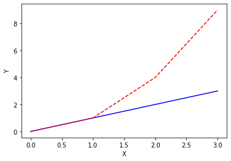

```python
plt.plot([0,1,2,3],[0,1,2,3],"-b",[0,1,2,3],[0,1,4,9],"--r")
plt.ylabel("Y")
plt.xlabel("X")
plt.show() #not actually necessary in notebook
```

# matplotlib is *stateful*

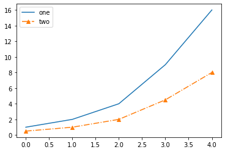

```python
plt.plot([1,2,4,9,16],label="one") #if only one data set is provide, assume uniform x
plt.plot([0.5,1,2,4.5,8],'^-.',label="two") #keep adding to current graph until show is called
plt.legend() #uses labels
plt.show()
```

```python
plt.show() # this doesn't show anything since we haven't created another plot
plt.close() #another way to finish with a plot
```

If you use the `%matplotlib` command in ipython, the plot will be updated with every command (can skip `show`)

# Format codes

```
marker	description
”.”	point
”,”	pixel
“o”	circle
“v”	triangle_down
“^”	triangle_up
“<”	triangle_left
“>”	triangle_right
“1”	tri_down
“2”	tri_up
“3”	tri_left
“4”	tri_right
“8”	octagon
“s”	square
“p”	pentagon
“*”	star
“h”	hexagon1
“H”	hexagon2
“+”	plus
“x”	x
“D”	diamond
“d”	thin_diamond
“|”	vline
“_”	hline
```

# Colors

```
    'b'         blue
    'g'         green
    'r'         red
    'c'         cyan
    'm'         magenta
    'y'         yellow
    'k'         black
    'w'         white
```

Can also specify colors with full names or hexadecimal

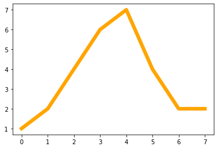

```python
plt.plot([1,2,4,6,7,4,2,2],'orange',linewidth=6)
plt.show()
```

# Plotting expression data

```python
f = open('../files/Spellman.txt')
header = f.readline().rstrip().split(',')#rstrip removes newline
data = []
for line in f:
    data.append(line.rstrip().split(','))
len(data)
```

```
4381
```

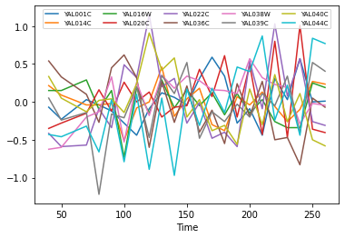

```python
for row in data[:10]: #first 10 only
    values = list(map(float, row[1:]))
    times = list(map(int, header[1:]))
    plt.plot(times,values,label=row[0])
plt.legend(loc='upper center',ncol=5,prop={'size':7})
plt.xlabel("Time");
```

Data conversion...

```python
for i in range(1,len(header)):
    header[i] = int(header[i])
    for r in range(len(data)):
        data[r][i] = float(data[r][i])
```

# Bar charts

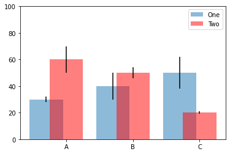

```python
plt.bar([1.1,2.1,3.1],[30,40,50],0.5,yerr=[2,10,12],ecolor="black",alpha=0.5,label="One")
plt.bar([1.4,2.4,3.4],[60,50,20],0.5,color='r',yerr=[10,4,1],ecolor="black",alpha=0.5,label="Two")
plt.xticks([1.4,2.4,3.4], ['A','B','C'])
plt.ylim([0,100])
plt.legend();
```

# Histograms

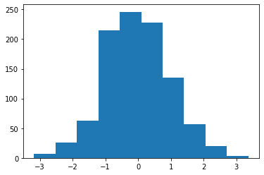

```python
import random
rdata = []
for i in range(1000):
    rdata.append(random.normalvariate(0,1))

plt.hist(rdata,10);
```

# Combining chart types

Just accumulate plots

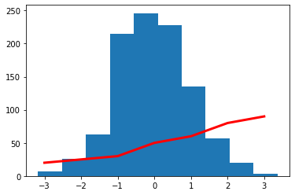

```python
plt.hist(rdata,10)
plt.plot([-3,-1,0,1,2,3],[20,30,50,60,80,90],'-r',linewidth=3)
plt.show()
```

# Terminology

### Figure

The full canvas you are creating your plot(s) on.

### Axes

A single plot

[figure not shown]

# Multiple Plots on a Figure

[subplots(nrows,ncols)](https://matplotlib.org/api/_as_gen/matplotlib.pyplot.subplots.html)

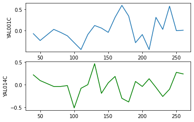

```python
fig, axes = plt.subplots(2,1)
plt.sca(axes[0]) #set current axis to first
plt.plot(header[1:],data[0][1:])
plt.ylabel(data[0][0])

plt.sca(axes[1])
plt.plot(header[1:],data[1][1:],'g')
plt.ylabel(data[1][0])
plt.show()
```

See also [GridSpec](http://matplotlib.org/users/gridspec.html)

# Multiple Plots on a Figure

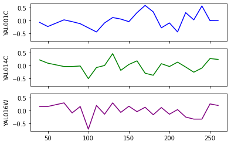

```python
numgenes = 3
fig, axes = plt.subplots(numgenes,1,sharex=True,sharey=True)
colors = ['b','g','purple']
for i in range(numgenes):
    #most plot methods have equivalents on axes objects
    axes[i].plot(header[1:],data[i][1:],color=colors[i])
    axes[i].set_ylabel(data[i][0])
```

# Exporting charts

Instead of `plt.show` use `plt.savefig`

`bbox_inches='tight'` tells matplotlib to try harder to fit everything nicely.

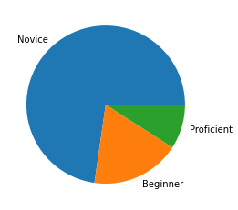

```python
plt.axes(aspect=1)
plt.pie([8,2,1],labels=["Novice","Beginner","Proficient"])
plt.savefig("pie.png",bbox_inches='tight')
```

```python
ls *png
```

```
pie.png
```

Other formats: pdf, svg, eps...

# Other chart types

[Gallery](http://matplotlib.org/gallery.html)

# Seaborn

Making (some) hard things easy

[Gallery](https://seaborn.pydata.org/examples/index.html)

# Project

https://MSCBIO2025.github.io/files/Spellman.csv

- plot a gene
- plot the histogram of initial expression levels
- plot the histogram of final expression levels
- plot the above histograms on the same plot with transparent fill
- plot the above with identical bin sizes for both histograms
- plot the above histograms on different subplots, vertically stacked